# RBIF112 - Assignment 5

Author: Neshita Kipuw

Last update: 01 October, 2025

```r
knitr::opts_chunk$set(echo = TRUE)
homedir <- "H:/My Drive/RBIF112/wk5/HW-files" # object containing a home directory path in R ( in this code chunk), and in python (The next code chunk).
setwd(homedir)
```

# 1 Question 1

Apply classification using logistic regression and naïve Bayes.

## 1.1 Data download

```r
# load packages
library(TCGAbiolinks)
library(EDASeq)
library(tibble)

# data download
# 133 breast cancer and control samples from the TCGA-BRCA project
# getProjectSummary() function returns information about what genomics data is
# available for a specific project
TCGAbiolinks:::getProjectSummary("TCGA-BRCA")
```

```
## $file_count
## [1] 71079
##
## $data_categories
##    file_count case_count                data_category
## 1       21437       1098  Simple Nucleotide Variation
## 2        9282       1098             Sequencing Reads
## 3        5317       1098                  Biospecimen
## 4        2288       1098                     Clinical
## 5       14346       1098        Copy Number Variation
## 6        4876       1097      Transcriptome Profiling
## 7        3714       1097              DNA Methylation
## 8         919        881           Proteome Profiling
## 9        3128        927 Somatic Structural Variation
## 10       5772       1098         Structural Variation
##
## $case_count
## [1] 1098
##
## $file_size
## [1] 6.249973e+14
```

```r
# download and prepare target case
# GDCquery() function grabs Transcriptome Profiling data from the TCGA-BRCA database
# the Transcriptome data is passed onto the getResults() function that returns
# the file names and ids that can be downloaded.
TargetSamples <- GDCquery(project = "TCGA-BRCA",
                         data.category = "Transcriptome Profiling",
                         data.type = "Gene Expression Quantification",
                         workflow.type = "STAR - Counts")

# obtain case information
CaseInfo <- getResults(TargetSamples)#, cols = c("cases"))
as_tibble(head(CaseInfo))
```

```
## # A tibble: 6 × 30
##   id         data_format cases access file_name submitter_id data_category type
##   <chr>      <chr>       <chr> <chr>  <chr>     <chr>        <chr>         <chr>
## 1 3396edba-… TSV         TCGA… open   2e64abe2… f7c166d0-fb… Transcriptom… gene…
## 2 d2e2915c-… TSV         TCGA… open   96a45a70… b67c7992-83… Transcriptom… gene…
## 3 fb32f0b1-… TSV         TCGA… open   1d468785… 70ea5a0a-27… Transcriptom… gene…
## 4 de5e449b-… TSV         TCGA… open   748e4eaa… 62faa455-eb… Transcriptom… gene…
## 5 a58e2ae3-… TSV         TCGA… open   e614fbb4… a2711d68-69… Transcriptom… gene…
## 6 f7b5d569-… TSV         TCGA… open   ad8c55ae… bcdf2a68-2d… Transcriptom… gene…
## # ℹ 22 more variables: platform <chr>, file_size <int>, created_datetime <chr>,
## #   md5sum <chr>, updated_datetime <chr>, file_id <chr>, data_type <chr>,
## #   state <chr>, experimental_strategy <chr>, version <chr>,
## #   data_release <chr>, project <chr>, analysis_id <chr>, analysis_state <chr>,
## #   analysis_submitter_id <chr>, analysis_workflow_link <chr>,
## #   analysis_workflow_type <chr>, analysis_workflow_version <chr>,
## #   sample_type <chr>, is_ffpe <lgl>, cases.submitter_id <chr>, …
```

```r
# subset samples so that there is an equal number of cancer and control samples
# 113 cancer and control data sets are downloaded
dataPrimary_Target <- TCGAquery_SampleTypes(barcode = CaseInfo$cases, typesample = "TP") # primary tumor
dataNormal_Target <- TCGAquery_SampleTypes(barcode = CaseInfo$cases, typesample = "NT") # normal tissue
dataPrimary_Target <- dataPrimary_Target[1:113]
dataNormal_Target <- dataNormal_Target[1:113]

# downloaded samples of interest
TargetSamples <- GDCquery(project = "TCGA-BRCA",
                             data.category = "Transcriptome Profiling",
                             data.type = "Gene Expression Quantification",
                             workflow.type = "STAR - Counts",
                             barcode = c(dataPrimary_Target, dataNormal_Target))

# Download the data (Note: Depending on your computer, you may not have enough RAM
# to process this amount of data. If this happens, please subset the data to
# include 50 cancer and 50 normal tissue samples)
#GDCdownload(TargetSamples) ## ALREADY downloaded 226 files and about 960 MB of data ##
```

## 1.2 Data Preparation (Normalization)

The TCGAbiolinks package contains pre-scripted functions that handle the downloaded data and format it into a summarizedExperiment object. A new variable will contain all of the meta data, and the meta data that is associated with the raw data set.

```r
# access the downloaded data
data <- GDCprepare(TargetSamples)
# look at list
assays(data)
```

```
## List of length 6
## names(6): unstranded stranded_first ... fpkm_unstrand fpkm_uq_unstrand
```

```r
# look at column metadata
as_tibble(colData(data))
```

```
## # A tibble: 226 × 97
##    barcode         patient sample shortLetterCode definition sample_submitter_id
##    <chr>           <chr>   <chr>  <chr>           <chr>      <chr>
##  1 TCGA-GM-A2DL-0… TCGA-G… TCGA-… TP              Primary s… TCGA-GM-A2DL-01A
##  2 TCGA-AC-A2QI-0… TCGA-A… TCGA-… TP              Primary s… TCGA-AC-A2QI-01A
##  3 TCGA-A8-A06R-0… TCGA-A… TCGA-… TP              Primary s… TCGA-A8-A06R-01A
##  4 TCGA-EW-A1PD-0… TCGA-E… TCGA-… TP              Primary s… TCGA-EW-A1PD-01A
##  5 TCGA-AO-A12D-0… TCGA-A… TCGA-… TP              Primary s… TCGA-AO-A12D-01A
##  6 TCGA-AR-A24N-0… TCGA-A… TCGA-… TP              Primary s… TCGA-AR-A24N-01A
##  7 TCGA-AR-A24U-0… TCGA-A… TCGA-… TP              Primary s… TCGA-AR-A24U-01A
##  8 TCGA-D8-A1JU-0… TCGA-D… TCGA-… TP              Primary s… TCGA-D8-A1JU-01A
##  9 TCGA-A8-A0AD-0… TCGA-A… TCGA-… TP              Primary s… TCGA-A8-A0AD-01A
## 10 TCGA-E2-A3DX-0… TCGA-E… TCGA-… TP              Primary s… TCGA-E2-A3DX-01A
## # ℹ 216 more rows
## # ℹ 91 more variables: sample_type_id <chr>, tumor_descriptor <chr>,
## #   sample_id <chr>, sample_type <chr>, composition <chr>,
## #   days_to_collection <int>, state <chr>, initial_weight <dbl>,
## #   preservation_method <chr>, pathology_report_uuid <chr>, submitter_id <chr>,
## #   oct_embedded <chr>, specimen_type <chr>, is_ffpe <lgl>, tissue_type <chr>,
## #   synchronous_malignancy <chr>, ajcc_pathologic_stage <chr>, …
```

```r
# look at row metadata
as_tibble(rowData(data))
```

```
## # A tibble: 60,660 × 10
##    source type  score phase gene_id            gene_type gene_name level hgnc_id
##    <fct>  <fct> <dbl> <int> <chr>              <chr>     <chr>     <chr> <chr>
##  1 HAVANA gene     NA    NA ENSG00000000003.15 protein_… TSPAN6    2     HGNC:1…
##  2 HAVANA gene     NA    NA ENSG00000000005.6  protein_… TNMD      2     HGNC:1…
##  3 HAVANA gene     NA    NA ENSG00000000419.13 protein_… DPM1      2     HGNC:3…
##  4 HAVANA gene     NA    NA ENSG00000000457.14 protein_… SCYL3     2     HGNC:1…
##  5 HAVANA gene     NA    NA ENSG00000000460.17 protein_… C1orf112  2     HGNC:2…
##  6 HAVANA gene     NA    NA ENSG00000000938.13 protein_… FGR       2     HGNC:3…
##  7 HAVANA gene     NA    NA ENSG00000000971.16 protein_… CFH       1     HGNC:4…
##  8 HAVANA gene     NA    NA ENSG00000001036.14 protein_… FUCA2     2     HGNC:4…
##  9 HAVANA gene     NA    NA ENSG00000001084.13 protein_… GCLC      1     HGNC:4…
## 10 HAVANA gene     NA    NA ENSG00000001167.14 protein_… NFYA      2     HGNC:7…
## # ℹ 60,650 more rows
## # ℹ 1 more variable: havana_gene <chr>
```

```r
# look at gene_type
table(rowData(data)$gene_type)
```

```
##
##                          IG_C_gene                    IG_C_pseudogene
##                                 14                                  9
##                          IG_D_gene                          IG_J_gene
##                                 37                                 18
##                    IG_J_pseudogene                      IG_pseudogene
##                                  3                                  1
##                          IG_V_gene                    IG_V_pseudogene
##                                145                                187
##                             lncRNA                              miRNA
##                              16901                               1881
##                           misc_RNA                            Mt_rRNA
##                               2212                                  2
##                            Mt_tRNA             polymorphic_pseudogene
##                                 22                                 48
##               processed_pseudogene                     protein_coding
##                              10167                              19962
##                         pseudogene                           ribozyme
##                                 18                                  8
##                               rRNA                    rRNA_pseudogene
##                                 47                                497
##                             scaRNA                              scRNA
##                                 49                                  1
##                             snoRNA                              snRNA
##                                943                               1901
##                               sRNA                                TEC
##                                  5                               1057
##                          TR_C_gene                          TR_D_gene
##                                  6                                  4
##                          TR_J_gene                    TR_J_pseudogene
##                                 79                                  4
##                          TR_V_gene                    TR_V_pseudogene
##                                106                                 33
##   transcribed_processed_pseudogene     transcribed_unitary_pseudogene
##                                500                                138
## transcribed_unprocessed_pseudogene    translated_processed_pseudogene
##                                939                                  2
##  translated_unprocessed_pseudogene                 unitary_pseudogene
##                                  1                                 98
##             unprocessed_pseudogene                          vault_RNA
##                               2614                                  1
```

```r
# grab the protein_coding data from SummarizedExperiment
SEcoding <- data[rowData(data)$ gene_type == "protein_coding", ]
# The following function will return the data from specified slots in
# the summarizedExperiment object
dataPrep_Coding <- TCGAanalyze_Preprocessing(object = SEcoding,
                                             cor.cut = 0.6,
                                             datatype = "fpkm_unstrand")

# data (quantile) normalization
# TCGAanalyze_Normalization() function is obtained from TCGAbiolinks package and
# will perform normalization, then filter samples with TCGAanalyze_Filtering()
dataNorm_Coding <- TCGAanalyze_Normalization(tabDF = dataPrep_Coding, geneInfo = geneInfoHT, method = "geneLength")
dataFilt_Coding <- TCGAanalyze_Filtering(tabDF = dataPrep_Coding, method = "quantile", qnt.cut =  0.25)
```

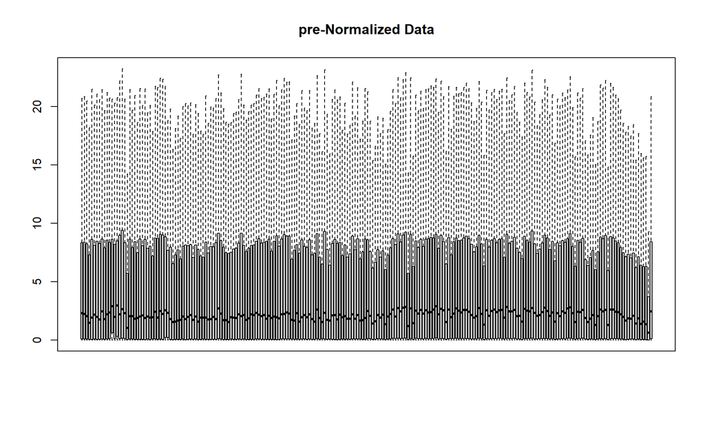

```r
# explore data using box plot
# look at the numeric values that are represented for each of the data sets
# downloaded, in order to assess for batch effects in the data.
boxplot(dataPrep_Coding, outline = FALSE, xaxt = "n", main = "pre-Normalized Data")
```

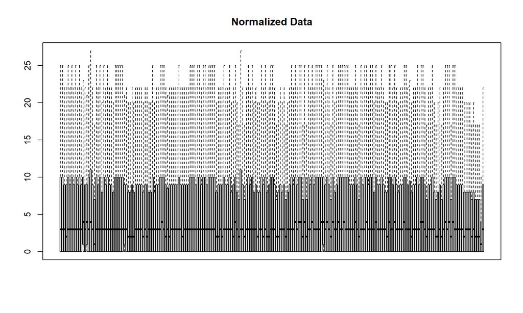

```r
# visualize the normalized and filtered data with box plot
boxplot(dataNorm_Coding, outline = FALSE, xaxt = "n", main = "Normalized Data")
```

## 1.3 Principal Components Analysis

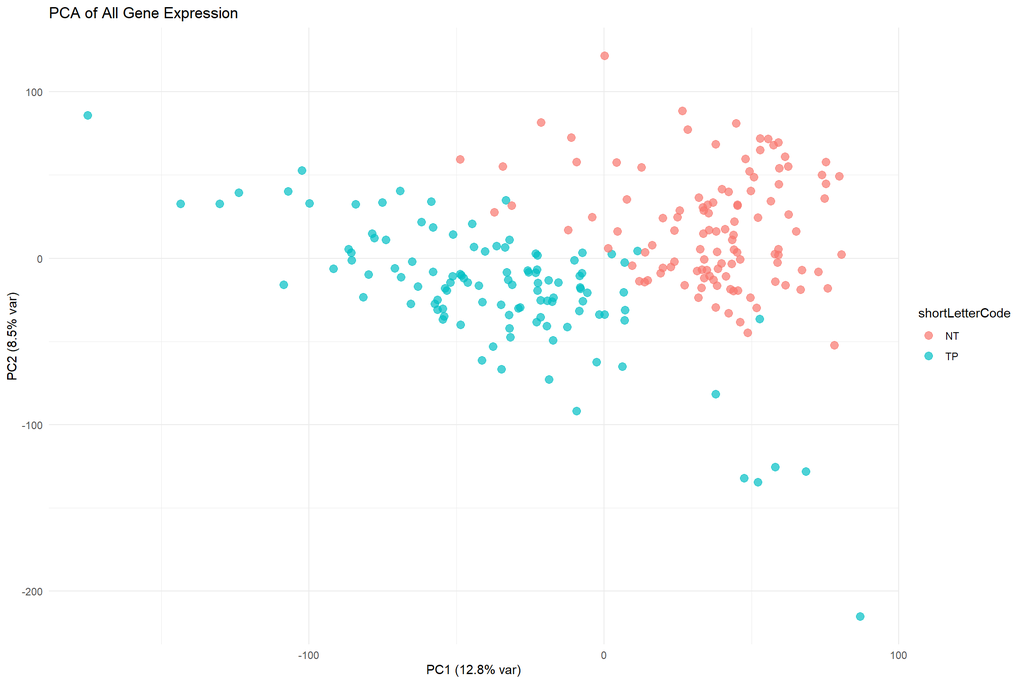

```r
## Use all expression data for PCA
library(preprocessCore)
library(ggplot2)

# get the expression matrix
expr_all <- assay(SEcoding)
# perform quantile normalization
expr_norm <- normalize.quantiles(as.matrix(expr_all))
# assign row names as expression matrix
rownames(expr_norm) <- rownames(expr_all)
# assign column names as expression matrix
colnames(expr_norm) <- colnames(expr_all)

# scale the data
expr_scaled <- t(scale(t(expr_norm)))
# transpose the expression matrix
expr_transpose <- t(expr_scaled)

# perform PCA
pca_result <- prcomp(expr_transpose, scale. = FALSE)

# prepare data for plotting
# create a data frame from the PCA results and the sample attributes
pca_df <- data.frame(pca_result$x,
                     colData(SEcoding))


## find the most significant genes in PC1 and PC2 (to be used later)
# get the loadings and make a data frame
pca_loads <- as.data.frame(pca_result$rotation)
# attach gene information to loadings
pca_loads$gene_id <- rowData(SEcoding)$gene_id
pca_loads$gene_name <- rowData(SEcoding)$gene_name


# plot PCA colored by a sample attribute (e.g. shortLetterCode)
# aes() function is used to map the variables to the x and y axes
# geom_point() function is used to create a scatter plot
# theme_minimal() function is used to create a minimal theme
# labs() function is used to add labels to the plot
ggplot(pca_df, aes(x = PC1, y = PC2, color = shortLetterCode)) +
  geom_point(size = 3, alpha = 0.7) +
  theme_minimal() +
  labs(title = paste("PCA of All Gene Expression"),
       x = paste0("PC1 (", round(100*summary(pca_result)$importance[2,1], 1), "% var)"),
       y = paste0("PC2 (", round(100*summary(pca_result)$importance[2,2], 1), "% var)"))
```

**Discussion:**  
The results of PCA analysis shows that PC1 explains 12.8% of the variance, while PC2 explains 8.5% of the variance. Together, PC1 and PC2 explain 21.3% of total variance, concentrating the most discriminating information into just two principal components. The distinct clustering indicates that NT and TP samples have fundamentally different gene expression profiles and showing genuine molecular differences between these conditions, making it likely that the logistic regression model will be successful. There is some overlap between groups in the central region, which will likely corresponds to misclassifications in the logistic regression model.

## 1.4 Data Exploration – Gene Correlation Analysis

```r
### Gene Correlation Analysis ###
library(SummarizedExperiment)
library(dplyr)
library(tibble)
library(purrr)


# 1. Get normalized expression matrix
expr_mat <- expr_norm

# 2. Get metadata
meta <- as.data.frame(colData(SEcoding))

# example continuous variables of interest
vars <- c("days_to_last_follow_up")

# ensure they exist
vars <- vars[vars %in% colnames(meta)]

# 3. Prepare output as list
results <- list()

# 4. Loop through continuous variables
for (i in vars) {
  # get the variables of interest
  y <- meta[[i]]

  # Keep only non-missing samples
  valid_samples <- which(!is.na(y))
  # subset the expression matrix for the valid samples
  expr_sub <- expr_mat[, valid_samples, drop = FALSE]
  # subset the variables of interest for the valid samples
  y_sub <- y[valid_samples]

  # Correlation per gene
  # will apply a function to each row of the expression matrix
  res <- apply(expr_sub, 1, function(x) {
    # calculate the spearman correlation between the expression and the variables
    ct <- suppressWarnings(cor.test(x, y_sub, method = "spearman"))
    # return the correlation and p-value
    c(cor = unname(ct$estimate),
      pval = ct$p.value)
  })
  # convert the results to a data frame
  res <- as.data.frame(t(res))
  # add the gene id and gene name
  res$gene_id <- rowData(SEcoding)$gene_id
  # add the gene name
  res$gene_name <- rowData(SEcoding)$gene_name
  # add the variable
  res$variable <- i
  # add the adjusted p-value
  res$padj <- p.adjust(res$pval, method = "fdr")
  # add the results to the list
  results[[i]] <- res
}

# 5. Combine into one dataframe
cor_results <- bind_rows(results)

# 6. Show top hits
top_hits <- cor_results %>%
  # take correlation results and arrange by adj pval & correlation value
  arrange(padj, desc(abs(cor))) %>%
  # select gene id, name, variable, correlation, pval & adj pvalues
  select(gene_id, gene_name, variable, cor, pval, padj)

# show the top 20 results
print(head(top_hits, 20))
```

```
##                               gene_id gene_name               variable
## ENSG00000175324.10 ENSG00000175324.10      LSM1 days_to_last_follow_up
## ENSG00000128346.11 ENSG00000128346.11  C22orf23 days_to_last_follow_up
## ENSG00000175482.9   ENSG00000175482.9     POLD4 days_to_last_follow_up
## ENSG00000149925.22 ENSG00000149925.22     ALDOA days_to_last_follow_up
## ENSG00000018408.15 ENSG00000018408.15     WWTR1 days_to_last_follow_up
## ENSG00000173545.5   ENSG00000173545.5    ZNF622 days_to_last_follow_up
## ENSG00000172201.12 ENSG00000172201.12       ID4 days_to_last_follow_up
## ENSG00000109654.16 ENSG00000109654.16     TRIM2 days_to_last_follow_up
## ENSG00000156076.10 ENSG00000156076.10      WIF1 days_to_last_follow_up
## ENSG00000104332.12 ENSG00000104332.12     SFRP1 days_to_last_follow_up
## ENSG00000135638.14 ENSG00000135638.14      EMX1 days_to_last_follow_up
## ENSG00000189292.16 ENSG00000189292.16    ALKAL2 days_to_last_follow_up
## ENSG00000091409.15 ENSG00000091409.15     ITGA6 days_to_last_follow_up
## ENSG00000206069.6   ENSG00000206069.6   TMEM211 days_to_last_follow_up
## ENSG00000006210.7   ENSG00000006210.7    CX3CL1 days_to_last_follow_up
## ENSG00000147862.17 ENSG00000147862.17      NFIB days_to_last_follow_up
## ENSG00000100902.11 ENSG00000100902.11     PSMA6 days_to_last_follow_up
## ENSG00000123415.15 ENSG00000123415.15     SMUG1 days_to_last_follow_up
## ENSG00000198681.7   ENSG00000198681.7    MAGEA1 days_to_last_follow_up
## ENSG00000276747.1   ENSG00000276747.1     PADI6 days_to_last_follow_up
##                           cor         pval         padj
## ENSG00000175324.10 -0.3819755 3.144406e-09 6.276862e-05
## ENSG00000128346.11  0.3538368 4.883370e-08 4.874092e-04
## ENSG00000175482.9  -0.3458180 1.017679e-07 6.615367e-04
## ENSG00000149925.22 -0.3428756 1.325592e-07 6.615367e-04
## ENSG00000018408.15  0.3370824 2.213084e-07 8.835517e-04
## ENSG00000173545.5  -0.3326080 3.264612e-07 9.650099e-04
## ENSG00000172201.12  0.3317597 3.511872e-07 9.650099e-04
## ENSG00000109654.16  0.3282669 4.732515e-07 9.650099e-04
## ENSG00000156076.10  0.3281631 4.774386e-07 9.650099e-04
## ENSG00000104332.12  0.3273645 5.108605e-07 9.650099e-04
## ENSG00000135638.14 -0.3268900 5.317658e-07 9.650099e-04
## ENSG00000189292.16  0.3228997 7.430970e-07 1.117831e-03
## ENSG00000091409.15  0.3216566 8.239429e-07 1.117831e-03
## ENSG00000206069.6   0.3205152 9.055233e-07 1.117831e-03
## ENSG00000006210.7   0.3203695 9.164793e-07 1.117831e-03
## ENSG00000147862.17  0.3200064 9.443360e-07 1.117831e-03
## ENSG00000100902.11 -0.3199087 9.519654e-07 1.117831e-03
## ENSG00000123415.15 -0.3165976 1.248415e-06 1.384492e-03
## ENSG00000198681.7  -0.3151395 1.405281e-06 1.476432e-03
## ENSG00000276747.1  -0.3140560 1.533856e-06 1.530941e-03
```

```r
paste("After correlation analysis, the most significant gene is:", top_hits$gene_name[1])
```

```
## [1] "After correlation analysis, the most significant gene is: LSM1"
```

```r
# assign top gene to a variable
top_geneid <- top_hits$gene_id[1]
top20 <- top_hits$gene_id[1:20]
```

**Discussion:**  
The gene correlation analysis identifies genes whose expression levels correlate most strongly with survival, recurrence, or treatment response (days to last follow up). The results are sorted by adjusted p-value significance and correlation strength. There are mixed correlations (positive and negative directions) suggesting a more complex biological relationships with survival or follow up time. All correlations are highly statistically significant, with adjusted p-values ranging from 10E-5 to 10E-3, indicating that the results are robust and reproducible associations unlikely to occur by chance. This result reveals prognostic gene signatures associated with follow-up time, and reflects fundamental differences in the molecular state of the disease.

## 1.5 Logistic Regression

The logistic regression below will take in the most significant genes from the **PCA analysis**, based on the loadings.

```r
library(caret)
library(glmnet)
library(pROC)
library(dplyr)

# 1. Define outcome: normal (0) vs breast cancer (1)
# grab column data from SEcoding as previous
#meta <- as.data.frame(colData(SEcoding))
# create a new column in the meta data frame with the outcome
# if the sample type is tumor the outcome is 1, otherwise it's 0
meta$breast_cancer <- ifelse(grepl("tumor", meta$sample_type, ignore.case = TRUE), 1, 0)

# count the number of 1s and 0s in the outcome to check balance
table(meta$breast_cancer)
```

```
##
##   0   1
## 113 113
```

```r
# 2. Get normalized expression matrix from previous
#expr_norm <- normalize.quantiles(as.matrix(expr_all))

# 3. Get the most significant gene in PC1
pca1_gene <- pca_loads %>%
  # arrange by absolute value of PC1
  arrange(desc(PC1)) %>%
  # select the top 20 genes
  head(20) %>%
  # select the gene id, gene name, and PC1
  select(gene_id, gene_name, PC1)
# print the most significant gene in PC1
paste("The most significant gene in PC1 is, gene ID:", pca1_gene[1,1], ", gene name:", pca1_gene[1,2])
```

```
## [1] "The most significant gene in PC1 is, gene ID: ENSG00000100731.16 , gene name: PCNX1"
```

```r
# 4. Get the most significant gene in PC2
pca2_gene <- pca_loads %>%
  arrange(desc(PC2)) %>%
  head(20) %>%
  select(gene_id, gene_name, PC2)
# print the most significant gene in PC2
paste("The most significant gene in PC2 is:", pca2_gene[1,2])
```

```
## [1] "The most significant gene in PC2 is: TNFSF12"
```

```r
# 5. Build data frame to put all together
# need variable for outcome as a factor, level is 0 or 1
outcome <- meta$breast_cancer
# convert to a factor
outcome <- factor(outcome, levels = c(0,1))

# assign new variable for the normalized expression matrix
expr_norm2 <- expr_norm

# assign new variables for the most significant genes in PC1 & PC2
# this will be used to subset the data for the model
pc1_top <- pca1_gene[1,1]
pc2_top <- pca2_gene[1,1]

# 6. Logistic regression with one gene
# formula: outcome ~ expression matrix of most significant gene in PC1
model1 <- glm(outcome ~ expr_norm2[pc1_top, ], family = "binomial")
# print to show some details about the model fit
model1
```

```
##
## Call:  glm(formula = outcome ~ expr_norm2[pc1_top, ], family = "binomial")
##
## Coefficients:
##           (Intercept)  expr_norm2[pc1_top, ]
##             4.7629511             -0.0009357
##
## Degrees of Freedom: 225 Total (i.e. Null);  224 Residual
## Null Deviance:       313.3
## Residual Deviance: 176.7     AIC: 180.7
```

```r
# print to show more details about the model fit
summary(model1)
```

```
##
## Call:
## glm(formula = outcome ~ expr_norm2[pc1_top, ], family = "binomial")
##
## Coefficients:
##                         Estimate Std. Error z value Pr(>|z|)
## (Intercept)            4.7629511  0.6037730   7.889 3.05e-15 ***
## expr_norm2[pc1_top, ] -0.0009357  0.0001151  -8.126 4.43e-16 ***
## ---
## Signif. codes:  0 '***' 0.001 '**' 0.01 '*' 0.05 '.' 0.1 ' ' 1
##
## (Dispersion parameter for binomial family taken to be 1)
##
##     Null deviance: 313.30  on 225  degrees of freedom
## Residual deviance: 176.72  on 224  degrees of freedom
## AIC: 180.72
##
## Number of Fisher Scoring iterations: 5
```

```r
# print the predicted values for the first 5 samples
# "type=response" will return the predicted probabilities
predict(model1, type = "response")[1:5]
```

```
##         1         2         3         4         5
## 0.9297330 0.8795946 0.8527610 0.3926826 0.8619530
```

```r
# 7. Logistic regression with two genes
model2 <- glm(outcome ~ expr_norm2[pc1_top, ] + expr_norm2[pc2_top, ], family = "binomial")
model2
```

```
##
## Call:  glm(formula = outcome ~ expr_norm2[pc1_top, ] + expr_norm2[pc2_top,
##     ], family = "binomial")
##
## Coefficients:
##           (Intercept)  expr_norm2[pc1_top, ]  expr_norm2[pc2_top, ]
##             10.167105              -0.001280              -0.002832
##
## Degrees of Freedom: 225 Total (i.e. Null);  223 Residual
## Null Deviance:       313.3
## Residual Deviance: 110.1     AIC: 116.1
```

```r
summary(model2)
```

```
##
## Call:
## glm(formula = outcome ~ expr_norm2[pc1_top, ] + expr_norm2[pc2_top,
##     ], family = "binomial")
##
## Coefficients:
##                         Estimate Std. Error z value Pr(>|z|)
## (Intercept)           10.1671052  1.3523279   7.518 5.55e-14 ***
## expr_norm2[pc1_top, ] -0.0012796  0.0001728  -7.406 1.30e-13 ***
## expr_norm2[pc2_top, ] -0.0028318  0.0004754  -5.957 2.58e-09 ***
## ---
## Signif. codes:  0 '***' 0.001 '**' 0.01 '*' 0.05 '.' 0.1 ' ' 1
##
## (Dispersion parameter for binomial family taken to be 1)
##
##     Null deviance: 313.3  on 225  degrees of freedom
## Residual deviance: 110.1  on 223  degrees of freedom
## AIC: 116.1
##
## Number of Fisher Scoring iterations: 6
```

```r
predict(model2, type = "response")[1:5]
```

```
##         1         2         3         4         5
## 0.9726380 0.9511225 0.9640356 0.7740583 0.9750384
```

```r
## checking the feature with the most predictive outcome with anova test
anova1 <- anova(model1, test = "Chisq")
print(anova1)
```

```
## Analysis of Deviance Table
##
## Model: binomial, link: logit
##
## Response: outcome
##
## Terms added sequentially (first to last)
##
##
##                       Df Deviance Resid. Df Resid. Dev  Pr(>Chi)
## NULL                                    225     313.30
## expr_norm2[pc1_top, ]  1   136.58       224     176.72 < 2.2e-16 ***
## ---
## Signif. codes:  0 '***' 0.001 '**' 0.01 '*' 0.05 '.' 0.1 ' ' 1
```

```r
anova2 <- anova(model2, test = "Chisq")
print(anova2)
```

```
## Analysis of Deviance Table
##
## Model: binomial, link: logit
##
## Response: outcome
##
## Terms added sequentially (first to last)
##
##
##                       Df Deviance Resid. Df Resid. Dev  Pr(>Chi)
## NULL                                    225     313.30
## expr_norm2[pc1_top, ]  1  136.582       224     176.72 < 2.2e-16 ***
## expr_norm2[pc2_top, ]  1   66.622       223     110.10 3.289e-16 ***
## ---
## Signif. codes:  0 '***' 0.001 '**' 0.01 '*' 0.05 '.' 0.1 ' ' 1
```

**Discussion:**  
The information obtained from model 1 summary using the top gene from PC1 showed a highly significant coefficient -9.4E-4, indicating that higher expression of this gene is associated with a lower probability of the outcome. With the addition of the top gene from PC2, the PC1 gene coefficient is still highly significant and negative, and PC2 gene coefficient is also highly significant (-2.8E-3) with a stronger effect than the PC1 gene (~2x larger coefficient). Both genes independently contribute to predicting the outcome, and both have negative coefficients, suggesting higher expression of either gene is associated with reduced odds of the outcome. Model 2 is better as the large decrease in both deviance and AIC indicates that the PC2 gene adds meaningful predictive information beyond the PC1 gene.

The ANOVA results shows how much each predictor contributes to improving the model when added in order. When the top gene from PC1 is added first, it captures >67% of the total explainable deviance and the p-value is extremely significant at 2.26E-16. This shows that this gene alone explains a significant amount of variation in the outcome and it is highly predictive. When the top gene from PC2 is added second, the deviance reduction is moderate but the p-value is still highly significant at 3.3E-16. Even after the PC1 gene, the PC2 gene provides a substantial addition of predictive power and explains complementary information not captured by PC1 gene. In this case, the order matters as PC1 gets the credit for all shared predictive power; However, both genes remain highly significant regardless of order and they both contribute uniquely. The top gene from PC1 is the strongest single predictor of the outcome, but combining it with PC2 gene created a significantly better model.

```r
## Assess Prediction ##

assess.prediction <- function(truth,predicted) {
  # exclude NA values from predicted and truth variables
  predicted = predicted[! is.na(truth)]
  truth = truth[! is.na(truth)]
  truth = truth[! is.na(predicted)]
  predicted = predicted[! is.na(predicted)]
  # print the total number of cases that are not NA
  cat("Total cases that are not NA: ",length(truth),"\n",sep="")
  # print the correct predictions or accuracy
  cat("Correct predictions (accuracy): ",sum(truth==predicted), "(",signif(sum(truth==predicted)*100/length(truth),3),"%)\n",sep="")
  # calculate the true positive rate, true negative rate, positive predictive value,
  # false discovery rate, and false positive rate
  TP = sum(truth==1 & predicted==1)
  TN = sum(truth==0 & predicted==0)
  FP = sum(truth==0 & predicted==1)
  FN = sum(truth==1 & predicted==0)
  # calculate the total number of positive and negative cases
  P = TP+FN
  N = FP+TN
  # print the true positive rate, true negative rate, positive predictive value,
  # false discovery rate, and false positive rate.
  # report results in percentage (hence 100*) and 3 decimal places
  cat("TPR (sensitivity)=TP/P: ", signif(100*TP/P,3),"%\n",sep="")
  cat("TNR (specificity)=TN/N: ", signif(100*TN/N,3),"%\n",sep="")
  cat("PPV (precision)=TP/(TP+FP): ", signif(100*TP/(TP+FP),3),"%\n",sep="")
  cat("FDR (false discovery)=1-PPV: ", signif(100*FP/(TP+FP),3),"%\n",sep="")
  cat("FPR =FP/N=1-TNR: ", signif(100*FP/N,3),"%\n",sep="")
}

## Assess predictions for model1 (one gene)
# make predictions with threshold larger than 0.5
assess.prediction(outcome, as.numeric(predict(model1, type="response") > 0.5))
```

```
## Total cases that are not NA: 226
## Correct predictions (accuracy): 194(85.8%)
## TPR (sensitivity)=TP/P: 85.8%
## TNR (specificity)=TN/N: 85.8%
## PPV (precision)=TP/(TP+FP): 85.8%
## FDR (false discovery)=1-PPV: 14.2%
## FPR =FP/N=1-TNR: 14.2%
```

```r
## Assess predictions for model2 (two genes)
# make predictions with threshold larger than 0.5
assess.prediction(outcome, as.numeric(predict(model2, type="response") > 0.5))
```

```
## Total cases that are not NA: 226
## Correct predictions (accuracy): 204(90.3%)
## TPR (sensitivity)=TP/P: 89.4%
## TNR (specificity)=TN/N: 91.2%
## PPV (precision)=TP/(TP+FP): 91%
## FDR (false discovery)=1-PPV: 9.01%
## FPR =FP/N=1-TNR: 8.85%
```

**Discussion:**  
The prediction assessment for model 1 show all metrics are identical at 85.8%, indicating balanced performance across positive and negative classes. With 85.8% accuracy the model correctly classifies 194/226 cases and the positive prediction is correct 85.8% of the time (PPV). The model shows that it detected 85.8% of true positive and true negative cases, but it has a false positive and false negative rates of 14.2% each.  
On the other hand, by adding a second gene model 2 improved accuracy by correctly classifying 204/226 cases or 90.3% (a 4.5% increase from model 1). When predicting positives (PPV) it is correct 91% of the time, a 5.2% increase. This model was slightly better at identifying true negative cases at 91.2% (5.4% increase), while sensitivity for true positive cases is 89.4% (3.6% increase). Additionally, the false discovery and false positive rates are reduced to 9.0% and 8.8%, respectively, showing a 5% reduction.  
The top gene from PC1 was quite informative achieving >85% across all metrics in model 1. However, model 2 is clearly superior as it correctly classified 10 additional cases and achieving over 90% accuracy with balanced sensitivity and specificity. The addition of the PC2 gene translates the improved statistical fit, making it the preferred model for making predictions.